# Generative AI in Croatian Education

Author

Lux

Published

December 15, 2025

# Executive Summary

# 1 Introduction

## 1.1 Background

The release of ChatGPT in November 2022 triggered a global conversation about artificial intelligence in education. Croatia, like many countries, witnessed intense media debate about the implications of generative AI for students, teachers, and educational institutions.

## 1.2 Research Questions

This analysis addresses four core questions:

1. **Volume & Timing**: How much coverage exists, and when did it peak?
2. **Framing**: Which interpretive frames dominate, and how do they shift over time?
3. **Actors**: Who is represented in coverage, and who is given voice?
4. **Sources**: Do different media types frame AI in education differently?

## 1.3 Theoretical Framework

Our analysis draws on:

- **Framing Theory** (Entman, 1993): Media frames as patterns of selection and emphasis
- **Moral Panic Theory** (Cohen, 1972): Technology adoption often follows panic cycles
- **Diffusion of Innovations** (Rogers, 1962): Media coverage mirrors adoption stages

# 2 Data and Methods

## 2.1 Data Source

```r
# ==============================================================================
# DATA LOADING
# ==============================================================================

# Use the configured path, or try to find the file
if (exists("DATA_FILE_PATH") && file.exists(DATA_FILE_PATH)) {
  data_file <- DATA_FILE_PATH
} else {
  # Try multiple possible locations for the data file
  possible_paths <- c(
    "./dta.xlsx",
    "../dta.xlsx",
    "dta.xlsx",
    file.path(getwd(), "dta.xlsx"),
    "D:/LUKA/Academic/HKS/Clanci/AI u obrazovanju/dta.xlsx"
  )

  data_file <- NULL
  for (path in possible_paths) {
    if (file.exists(path)) {
      data_file <- path
      break
    }
  }

  if (is.null(data_file)) {
    cat("Current working directory:", getwd(), "\n")
    cat("Files in current directory:\n")
    print(list.files(pattern = "\\.xlsx$", recursive = TRUE))
    stop("Could not find dta.xlsx. Set DATA_FILE_PATH in the setup chunk.")
  }
}

cat("Loading data from:", data_file, "\n")
```

```
Loading data from: ./dta.xlsx
```

```r
# Load the pre-processed data
raw_data <- read.xlsx(data_file)

cat("Dataset loaded successfully\n")
```

```
Dataset loaded successfully
```

```r
cat("Total articles:", format(nrow(raw_data), big.mark = ","), "\n")
```

```
Total articles: 4,424
```

```r
cat("Columns:", ncol(raw_data), "\n")
```

```
Columns: 48
```

## 2.2 Data Processing

```r
# Validate and clean data
validated_data <- raw_data %>%
  filter(!is.na(FULL_TEXT) & !is.na(TITLE))

# Parse dates
clean_data <- validated_data %>%
  mutate(
    DATE = as.Date(DATE),
    year = year(DATE),
    month = month(DATE),
    year_month = floor_date(DATE, "month"),
    week = floor_date(DATE, "week"),
    quarter = quarter(DATE),
    word_count = str_count(FULL_TEXT, "\\S+"),
    article_id = row_number()
  ) %>%
  filter(!is.na(DATE)) %>%
  distinct(TITLE, DATE, .keep_all = TRUE) %>%
  arrange(DATE)

# Day of week
clean_data$day_of_week <- wday(clean_data$DATE, label = TRUE, abbr = FALSE)

cat("Articles after cleaning:", format(nrow(clean_data), big.mark = ","), "\n")
```

```
Articles after cleaning: 3,873
```

```r
cat("Date range:", as.character(min(clean_data$DATE)), "to", as.character(max(clean_data$DATE)), "\n")
```

```
Date range: 2021-01-01 to 2024-07-04
```

## 2.3 Frame Dictionaries

Frame detection employs a dictionary-based approach, where each frame is operationalized through a curated set of Croatian-language keywords. For each article, we count occurrences of dictionary terms in the combined title and body text. An article is coded as containing a frame if at least one dictionary term is present. The *dominant frame* is determined by the highest keyword count across all eight frames.

```r
frame_dictionaries <- list(
  THREAT = c(
    "prijetnja", "opasnost", "opasno", "rizik", "rizično",
    "varanje", "varati", "prevara", "plagijat", "plagiranje",
    "prepisivanje", "zabrana", "zabraniti", "zabranjeno",
    "uništiti", "uništava", "smrt", "kraj", "propast",
    "kriza", "alarm", "upozorenje", "šteta", "štetno",
    "strah", "bojati", "panika"
  ),

  OPPORTUNITY = c(
    "alat", "sredstvo", "pomoć", "pomoćnik", "asistent",
    "prilika", "mogućnost", "potencijal", "prednost", "korist",
    "poboljšati", "poboljšanje", "unaprijediti", "napredak",
    "učinkovit", "učinkovitost", "efikasan", "produktivnost",
    "budućnost", "inovacija", "inovativan", "revolucija",
    "moderan", "modernizacija", "transformacija",
    "uspjeh", "uspješno", "izvrsno"
  ),

  REGULATION = c(
    "pravilnik", "pravilo", "propisi", "regulativa",
    "smjernice", "upute", "protokol",
    "zakon", "zakonski", "pravni",
    "ministarstvo", "ministar", "vlada",
    "dopušteno", "dopuštenje", "dozvola",
    "primjena", "provedba", "implementacija",
    "odluka", "mjera"
  ),

  DISRUPTION = c(
    "promjena", "promijeniti", "transformacija", "preobrazba",
    "prilagodba", "prilagoditi", "adaptacija",
    "neizbježno", "nezaustavljivo",
    "revolucija", "prekretnica", "nova era", "novi način",
    "evolucija", "disrupcija"
  ),

  REPLACEMENT = c(
    "zamjena", "zamijeniti", "zamjenjuje", "istisnuti",
    "gubitak posla", "nepotreban", "suvišan", "zastario",
    "automatizacija", "automatizirano",
    "nadmašiti", "bolji od čovjeka"
  ),

  QUALITY = c(
    "halucinacija", "halucinacije", "greška", "greške",
    "netočno", "netočnost", "pogrešno",
    "pouzdanost", "pouzdan", "nepouzdan",
    "provjera", "provjeriti", "verifikacija",
    "kvaliteta", "kritički", "kritičko mišljenje"
  ),

  EQUITY = c(
    "nejednakost", "nejednako", "jaz", "razlika",
    "pristup", "pristupačnost", "dostupnost",
    "digitalni jaz", "siromašan", "socioekonomski",
    "pravednost", "pravedno", "nepravedno"
  ),

  COMPETENCE = c(
    "vještine", "vještina", "kompetencije",
    "sposobnost", "pismenost", "digitalna pismenost",
    "kritičko mišljenje", "analitičko mišljenje",
    "učiti", "obrazovanje", "edukacija", "usavršavanje"
  )
)

# Actor dictionaries
actor_dictionaries <- list(
  STUDENTS = c("student", "studenti", "učenik", "učenici", "đak", "maturant", "brucoš"),
  TEACHERS = c("učitelj", "učitelji", "nastavnik", "profesor", "profesori", "predavač", "mentor"),
  ADMINISTRATORS = c("ravnatelj", "dekan", "rektor", "prorektor", "voditelj"),
  INSTITUTIONS = c("škola", "škole", "fakultet", "sveučilište", "ministarstvo", "carnet"),
  TECH_COMPANIES = c("openai", "microsoft", "google", "chatgpt", "gpt", "gemini", "copilot"),
  EXPERTS = c("stručnjak", "ekspert", "znanstvenik", "istraživač", "analitičar"),
  POLICY_MAKERS = c("ministar", "zastupnik", "premijer", "vlada", "sabor")
)

# Sentiment dictionaries
sentiment_positive <- c(
  "dobar", "dobro", "odličan", "sjajan", "izvrstan", "fantastičan",
  "pozitivan", "uspješan", "uspjeh", "napredak", "poboljšanje",
  "zadovoljan", "optimizam", "nada", "kvalitetan", "koristan"
)

sentiment_negative <- c(
  "loš", "loše", "negativan", "grozan", "užasan", "katastrofa",
  "problem", "neuspjeh", "propast", "pogoršanje",
  "nezadovoljan", "razočaran", "pesimizam", "strah",
  "nekvalitetan", "beskoristan"
)

cat("Frame dictionaries created:", length(frame_dictionaries), "frames\n")
```

```
Frame dictionaries created: 8 frames
```

```r
cat("Actor dictionaries created:", length(actor_dictionaries), "actor types\n")
```

```
Actor dictionaries created: 7 actor types
```

## 2.4 Frame Detection

The detection algorithm iterates through each article, applying regular expression matching with word boundaries (`\b`) to avoid partial matches. Sentiment is computed as a simple difference score: *positive word count − negative word count*. Articles with scores above +2 are classified as positive, below −2 as negative, and the remainder as neutral. This threshold-based approach provides robustness against minor fluctuations while capturing meaningful sentiment differences.

```r
# Function to detect frames
detect_frames <- function(text, dictionaries) {
  if (is.na(text)) return(setNames(rep(0, length(dictionaries)), names(dictionaries)))
  text_lower <- str_to_lower(text)
  sapply(names(dictionaries), function(frame_name) {
    pattern <- paste0("\\b(", paste(dictionaries[[frame_name]], collapse = "|"), ")")
    sum(str_count(text_lower, pattern))
  })
}

detect_frame_presence <- function(text, dictionaries) {
  if (is.na(text)) return(setNames(rep(FALSE, length(dictionaries)), names(dictionaries)))
  text_lower <- str_to_lower(text)
  sapply(names(dictionaries), function(frame_name) {
    pattern <- paste0("\\b(", paste(dictionaries[[frame_name]], collapse = "|"), ")")
    str_detect(text_lower, pattern)
  })
}

# Apply frame analysis (with progress indicator)
message("Applying frame analysis...")

frame_results <- lapply(seq_len(nrow(clean_data)), function(i) {
  combined_text <- paste(clean_data$TITLE[i], clean_data$FULL_TEXT[i], sep = " ")

  frame_counts <- detect_frames(combined_text, frame_dictionaries)
  frame_presence <- detect_frame_presence(combined_text, frame_dictionaries)
  actor_counts <- detect_frames(combined_text, actor_dictionaries)
  actor_presence <- detect_frame_presence(combined_text, actor_dictionaries)

  # Sentiment
  text_lower <- str_to_lower(combined_text)
  pos_count <- sum(str_count(text_lower, paste0("\\b(", paste(sentiment_positive, collapse = "|"), ")")))
  neg_count <- sum(str_count(text_lower, paste0("\\b(", paste(sentiment_negative, collapse = "|"), ")")))

  c(
    setNames(frame_counts, paste0("frame_", names(frame_counts), "_count")),
    setNames(frame_presence, paste0("frame_", names(frame_presence), "_present")),
    setNames(actor_counts, paste0("actor_", names(actor_counts), "_count")),
    setNames(actor_presence, paste0("actor_", names(actor_presence), "_present")),
    sentiment_POSITIVE_count = pos_count,
    sentiment_NEGATIVE_count = neg_count
  )
})

frame_df <- bind_rows(lapply(frame_results, as.data.frame.list))
clean_data <- bind_cols(clean_data, frame_df)

# Calculate derived metrics
clean_data <- clean_data %>%
  mutate(
    dominant_frame = apply(
      select(., starts_with("frame_") & ends_with("_count") & !contains("frame_count")), 1,
      function(x) {
        frame_names <- c("THREAT", "OPPORTUNITY", "REGULATION", "DISRUPTION",
                         "REPLACEMENT", "QUALITY", "EQUITY", "COMPETENCE")
        if (all(x == 0)) return("NONE")
        frame_names[which.max(x)]
      }
    ),
    frame_intensity = rowSums(select(., starts_with("frame_") & ends_with("_count") & !contains("frame_count"))),
    frame_count = rowSums(select(., starts_with("frame_") & ends_with("_present"))),
    sentiment_score = sentiment_POSITIVE_count - sentiment_NEGATIVE_count,
    sentiment_category = case_when(
      sentiment_score > 2 ~ "Positive",
      sentiment_score < -2 ~ "Negative",
      TRUE ~ "Neutral"
    ),
    primary_actor = apply(
      select(., starts_with("actor_") & ends_with("_count")), 1,
      function(x) {
        actor_names <- c("STUDENTS", "TEACHERS", "ADMINISTRATORS", "INSTITUTIONS",
                         "TECH_COMPANIES", "EXPERTS", "POLICY_MAKERS")
        if (all(x == 0)) return("NONE")
        actor_names[which.max(x)]
      }
    ),
    narrative_phase = case_when(
      DATE < as.Date("2023-06-01") ~ "Phase 1: Emergence",
      DATE < as.Date("2024-01-01") ~ "Phase 2: Debate",
      DATE < as.Date("2024-09-01") ~ "Phase 3: Integration",
      TRUE ~ "Phase 4: Normalization"
    )
  )

cat("Frame analysis complete.\n")
```

```
Frame analysis complete.
```

```r
cat("Articles with at least one frame:", sum(clean_data$frame_count > 0), "\n")
```

```
Articles with at least one frame: 3154
```

# 3 Results

## 3.1 Coverage Overview

This section presents descriptive statistics characterizing the corpus. The percentage of articles with at least one detected frame indicates dictionary coverage—values below 70% may suggest dictionary expansion is needed.

### 3.1.1 Dataset Summary

```r
summary_stats <- tibble(
  Metric = c(
    "Total Articles",
    "Date Range",
    "Unique Sources",
    "Total Words Analyzed",
    "Mean Article Length (words)",
    "Articles with Frame Detected"
  ),
  Value = c(
    format(nrow(clean_data), big.mark = ","),
    paste(min(clean_data$DATE), "to", max(clean_data$DATE)),
    format(n_distinct(clean_data$FROM), big.mark = ","),
    format(sum(clean_data$word_count, na.rm = TRUE), big.mark = ","),
    format(round(mean(clean_data$word_count, na.rm = TRUE)), big.mark = ","),
    paste0(format(sum(clean_data$frame_count > 0), big.mark = ","),
           " (", round(mean(clean_data$frame_count > 0) * 100, 1), "%)")
  )
)

kable(summary_stats, align = c("l", "r")) %>%
  kable_styling(bootstrap_options = c("striped", "hover"), full_width = FALSE)
```

Table 1: Dataset Overview

| Metric | Value |
| --- | --- |
| Total Articles | 3,873 |
| Date Range | 2021-01-01 to 2024-07-04 |
| Unique Sources | 512 |
| Total Words Analyzed | 1,483,958 |
| Mean Article Length (words) | 383 |
| Articles with Frame Detected | 3,154 (81.4%) |

### 3.1.2 Temporal Distribution

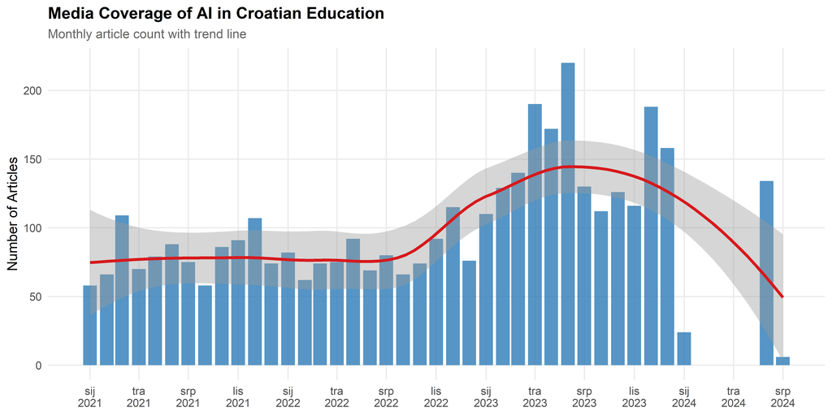

Figure 1: Monthly Coverage Volume

```r
monthly_stats <- clean_data %>%
  group_by(year_month) %>%
  summarise(
    n_articles = n(),
    prop_THREAT = mean(frame_THREAT_present, na.rm = TRUE),
    prop_OPPORTUNITY = mean(frame_OPPORTUNITY_present, na.rm = TRUE),
    prop_REGULATION = mean(frame_REGULATION_present, na.rm = TRUE),
    mean_sentiment = mean(sentiment_score, na.rm = TRUE),
    .groups = "drop"
  )

ggplot(monthly_stats, aes(x = year_month, y = n_articles)) +
  geom_col(fill = "#2c7bb6", alpha = 0.8) +
  geom_smooth(method = "loess", se = TRUE, color = "#d7191c", linewidth = 1.2) +
  scale_x_date(date_breaks = "3 months", date_labels = "%b\n%Y") +
  labs(
    title = "Media Coverage of AI in Croatian Education",
    subtitle = "Monthly article count with trend line",
    x = NULL,
    y = "Number of Articles"
  )
```

### 3.1.3 Day of Week Patterns

Publication timing reveals editorial routines. Weekday concentration suggests news-driven coverage, while weekend spikes may indicate feature or opinion pieces. Percentages sum to 100% across all days.

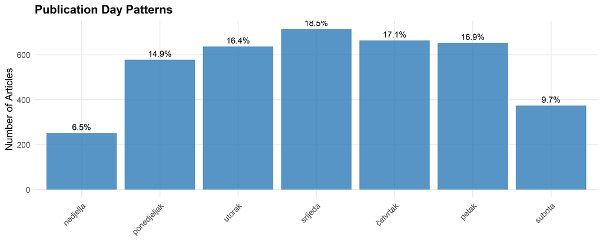

Figure 2: Publication Patterns by Day of Week

```r
dow_stats <- clean_data %>%
  filter(!is.na(day_of_week)) %>%
  count(day_of_week) %>%
  mutate(percentage = n / sum(n) * 100)

ggplot(dow_stats, aes(x = day_of_week, y = n)) +
  geom_col(fill = "#2c7bb6", alpha = 0.8) +
  geom_text(aes(label = paste0(round(percentage, 1), "%")), vjust = -0.5, size = 3.5) +
  labs(
    title = "Publication Day Patterns",
    x = NULL,
    y = "Number of Articles"
  ) +
  theme(axis.text.x = element_text(angle = 45, hjust = 1))
```

## 3.2 Frame Analysis

Frame analysis quantifies how media construct meaning around AI in education. Each article receives a dominant frame assignment based on maximum keyword frequency. Articles with zero matches across all dictionaries are coded as “NONE.”

### 3.2.1 Dominant Frames

The horizontal bar chart ranks frames by article count. Percentages indicate each frame’s share of total coverage. A high “NONE” proportion signals potential dictionary gaps or genuinely frame-neutral content.

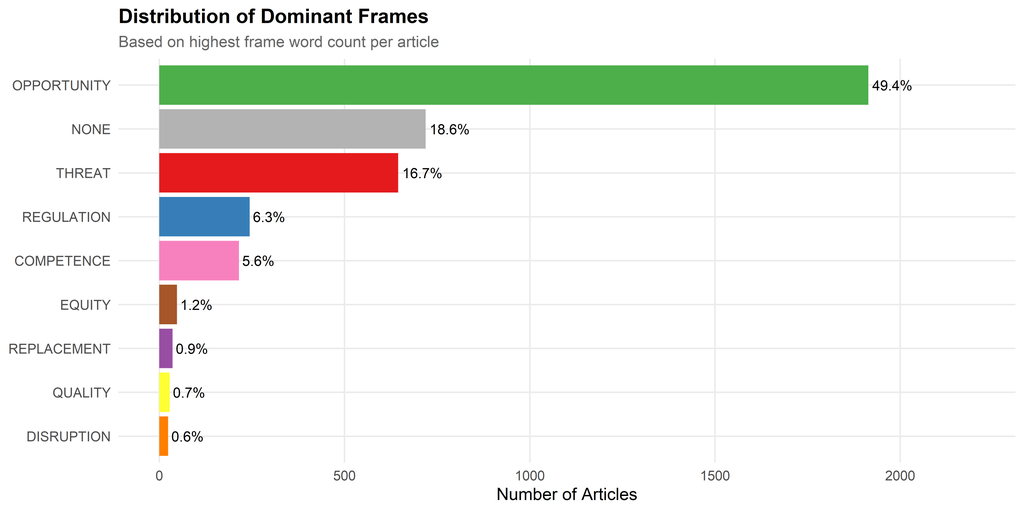

Figure 3: Distribution of Dominant Frames

```r
frame_dist <- clean_data %>%
  count(dominant_frame, sort = TRUE) %>%
  mutate(
    percentage = n / sum(n) * 100,
    dominant_frame = factor(dominant_frame, levels = dominant_frame)
  )

ggplot(frame_dist, aes(x = reorder(dominant_frame, n), y = n, fill = dominant_frame)) +
  geom_col() +
  geom_text(aes(label = paste0(round(percentage, 1), "%")), hjust = -0.1, size = 3.5) +
  scale_fill_manual(values = frame_colors) +
  coord_flip() +
  labs(
    title = "Distribution of Dominant Frames",
    subtitle = "Based on highest frame word count per article",
    x = NULL,
    y = "Number of Articles"
  ) +
  theme(legend.position = "none") +
  expand_limits(y = max(frame_dist$n) * 1.15)
```

### 3.2.2 Frame Evolution Over Time

This time series tracks the *proportion* of articles containing each frame per month (not mutually exclusive—articles may contain multiple frames). Rising lines indicate increasing frame salience; convergence suggests narrative consolidation.

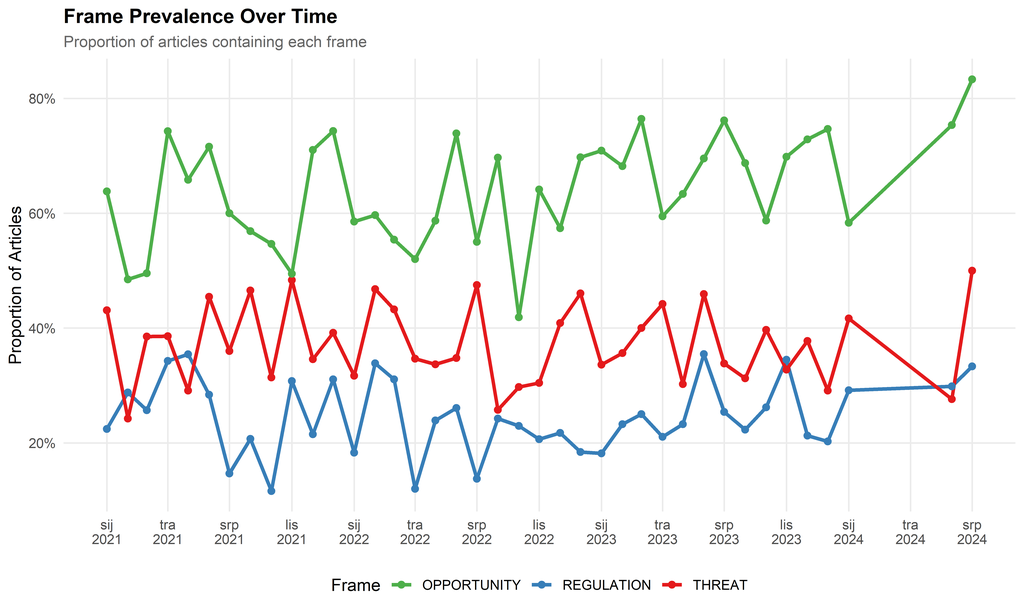

Figure 4: Evolution of Media Frames Over Time

```r
frame_evolution <- monthly_stats %>%
  select(year_month, prop_THREAT, prop_OPPORTUNITY, prop_REGULATION) %>%
  pivot_longer(-year_month, names_to = "frame", values_to = "proportion") %>%
  mutate(frame = str_remove(frame, "prop_"))

ggplot(frame_evolution, aes(x = year_month, y = proportion, color = frame)) +
  geom_line(linewidth = 1.2) +
  geom_point(size = 2) +
  scale_color_manual(values = frame_colors) +
  scale_y_continuous(labels = scales::percent) +
  scale_x_date(date_breaks = "3 months", date_labels = "%b\n%Y") +
  labs(
    title = "Frame Prevalence Over Time",
    subtitle = "Proportion of articles containing each frame",
    x = NULL,
    y = "Proportion of Articles",
    color = "Frame"
  )
```

### 3.2.3 Frame Co-occurrence

The heatmap displays normalized co-occurrence frequencies. Values are row-normalized by diagonal (self-occurrence), so each cell represents: *P(Frame₂ | Frame₁)*. Values approaching 1.0 indicate frames that frequently appear together; the diagonal is always 1.0 by definition.

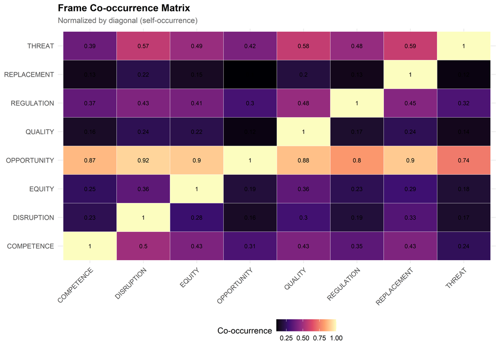

Figure 5: Frame Co-occurrence Matrix

```r
frame_cols <- clean_data %>%
  select(starts_with("frame_") & ends_with("_present"))

if (ncol(frame_cols) > 1) {
  frame_cooccur <- crossprod(as.matrix(frame_cols))
  diag_vals <- diag(frame_cooccur)
  diag_vals[diag_vals == 0] <- 1
  frame_cooccur_norm <- frame_cooccur / diag_vals

  frame_cooccur_df <- as.data.frame(frame_cooccur_norm)
  frame_cooccur_df$frame1 <- rownames(frame_cooccur_df)
  frame_cooccur_df <- frame_cooccur_df %>%
    pivot_longer(-frame1, names_to = "frame2", values_to = "cooccurrence") %>%
    mutate(
      frame1 = str_extract(frame1, "(?<=frame_)[A-Z]+"),
      frame2 = str_extract(frame2, "(?<=frame_)[A-Z]+")
    ) %>%
    filter(!is.na(frame1) & !is.na(frame2))

  ggplot(frame_cooccur_df, aes(x = frame1, y = frame2, fill = cooccurrence)) +
    geom_tile(color = "white") +
    geom_text(aes(label = round(cooccurrence, 2)), size = 3) +
    scale_fill_viridis_c(option = "magma") +
    labs(
      title = "Frame Co-occurrence Matrix",
      subtitle = "Normalized by diagonal (self-occurrence)",
      x = NULL, y = NULL, fill = "Co-occurrence"
    ) +
    theme(axis.text.x = element_text(angle = 45, hjust = 1))
}
```

## 3.3 Narrative Phases

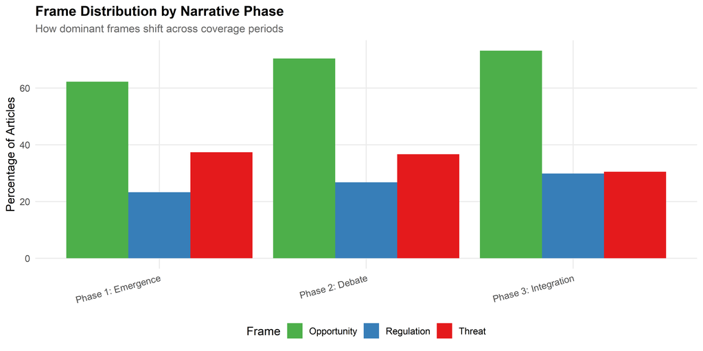

Figure 6: Frame Distribution by Narrative Phase

```r
phase_stats <- clean_data %>%
  group_by(narrative_phase) %>%
  summarise(
    n = n(),
    threat = mean(frame_THREAT_present, na.rm = TRUE) * 100,
    opportunity = mean(frame_OPPORTUNITY_present, na.rm = TRUE) * 100,
    regulation = mean(frame_REGULATION_present, na.rm = TRUE) * 100,
    .groups = "drop"
  ) %>%
  mutate(narrative_phase = factor(narrative_phase, levels = c(
    "Phase 1: Emergence", "Phase 2: Debate", "Phase 3: Integration", "Phase 4: Normalization"
  )))

phase_long <- phase_stats %>%
  select(narrative_phase, threat, opportunity, regulation) %>%
  pivot_longer(-narrative_phase, names_to = "frame", values_to = "percentage") %>%
  mutate(frame = str_to_title(frame))

ggplot(phase_long, aes(x = narrative_phase, y = percentage, fill = frame)) +
  geom_col(position = "dodge") +
  scale_fill_manual(values = c("Threat" = "#e41a1c", "Opportunity" = "#4daf4a", "Regulation" = "#377eb8")) +
  labs(
    title = "Frame Distribution by Narrative Phase",
    subtitle = "How dominant frames shift across coverage periods",
    x = NULL,
    y = "Percentage of Articles",
    fill = "Frame"
  ) +
  theme(axis.text.x = element_text(angle = 15, hjust = 1))
```

```r
phase_table <- clean_data %>%
  group_by(narrative_phase) %>%
  summarise(
    `Articles` = n(),
    `Date Range` = paste(min(DATE), "—", max(DATE)),
    `Mean Sentiment` = round(mean(sentiment_score, na.rm = TRUE), 2),
    `% Threat Frame` = paste0(round(mean(frame_THREAT_present, na.rm = TRUE) * 100, 1), "%"),
    `% Opportunity Frame` = paste0(round(mean(frame_OPPORTUNITY_present, na.rm = TRUE) * 100, 1), "%"),
    .groups = "drop"
  )

kable(phase_table) %>%
  kable_styling(bootstrap_options = c("striped", "hover"), full_width = FALSE)
```

Table 2: Summary Statistics by Narrative Phase

| narrative_phase | Articles | Date Range | Mean Sentiment | % Threat Frame | % Opportunity Frame |
| --- | --- | --- | --- | --- | --- |
| Phase 1: Emergence | 2659 | 2021-01-01 — 2023-05-31 | 0.07 | 37.4% | 62.2% |
| Phase 2: Debate | 1050 | 2023-06-01 — 2023-12-30 | 0.31 | 36.7% | 70.4% |
| Phase 3: Integration | 164 | 2024-01-02 — 2024-07-04 | 0.28 | 30.5% | 73.2% |

## 3.4 Sentiment Analysis

Sentiment provides an aggregate valence measure independent of specific frames. The trajectory plot shows monthly mean sentiment; green shading indicates positive territory, red indicates negative. Zero represents neutral balance between positive and negative lexicon matches.

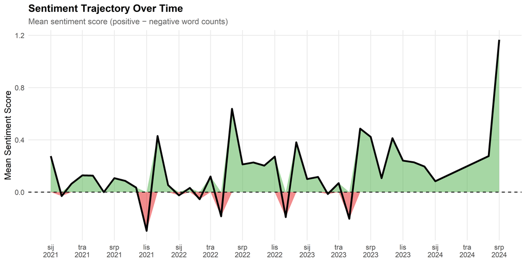

Figure 7: Sentiment Trajectory Over Time

```r
ggplot(monthly_stats, aes(x = year_month)) +
  geom_ribbon(aes(ymin = 0, ymax = pmax(mean_sentiment, 0)), fill = "#4daf4a", alpha = 0.5) +
  geom_ribbon(aes(ymin = pmin(mean_sentiment, 0), ymax = 0), fill = "#e41a1c", alpha = 0.5) +
  geom_line(aes(y = mean_sentiment), linewidth = 1.2, color = "black") +
  geom_hline(yintercept = 0, linetype = "dashed") +
  scale_x_date(date_breaks = "3 months", date_labels = "%b\n%Y") +
  labs(
    title = "Sentiment Trajectory Over Time",
    subtitle = "Mean sentiment score (positive − negative word counts)",
    x = NULL,
    y = "Mean Sentiment Score"
  )
```

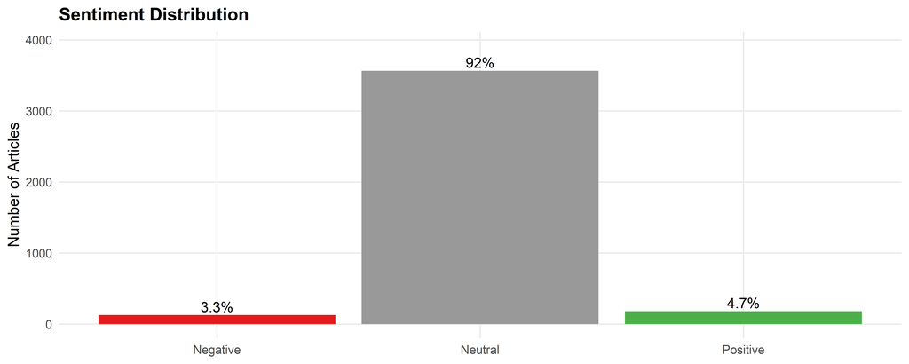

Figure 8: Distribution of Sentiment Categories

```r
sentiment_dist <- clean_data %>%
  count(sentiment_category) %>%
  mutate(percentage = n / sum(n) * 100)

ggplot(sentiment_dist, aes(x = sentiment_category, y = n, fill = sentiment_category)) +
  geom_col() +
  geom_text(aes(label = paste0(round(percentage, 1), "%")), vjust = -0.3, size = 4) +
  scale_fill_manual(values = sentiment_colors) +
  labs(
    title = "Sentiment Distribution",
    x = NULL,
    y = "Number of Articles"
  ) +
  theme(legend.position = "none") +
  expand_limits(y = max(sentiment_dist$n) * 1.1)
```

## 3.5 Actor Representation

Actor analysis identifies *who* is discussed in coverage. The primary actor is assigned based on highest mention count per article. This reveals whose perspectives dominate discourse and potential imbalances in voice allocation.

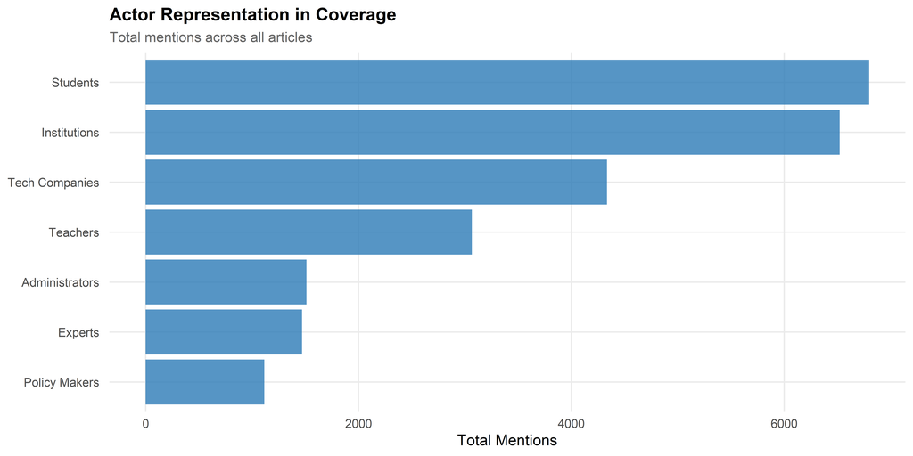

Figure 9: Actor Representation in Coverage

```r
actor_frequency <- clean_data %>%
  summarise(
    across(starts_with("actor_") & ends_with("_count"), sum),
    across(starts_with("actor_") & ends_with("_present"), sum)
  ) %>%
  pivot_longer(everything(), names_to = "metric", values_to = "value") %>%
  mutate(
    type = ifelse(str_detect(metric, "total_|_count"), "Total Mentions", "Articles Present"),
    actor = str_extract(metric, "(?<=actor_)[A-Z_]+") %>%
      str_replace_all("_", " ") %>%
      str_to_title()
  ) %>%
  filter(type == "Total Mentions") %>%
  arrange(desc(value))

ggplot(actor_frequency, aes(x = reorder(actor, value), y = value)) +
  geom_col(fill = "#2c7bb6", alpha = 0.8) +
  coord_flip() +
  labs(
    title = "Actor Representation in Coverage",
    subtitle = "Total mentions across all articles",
    x = NULL,
    y = "Total Mentions"
  )
```

The actor-frame association chart shows which frames co-occur with each primary actor. This reveals differential framing: for instance, if policy makers are more frequently associated with regulation frames, this suggests their media presence centers on governance rather than opportunity or threat narratives.

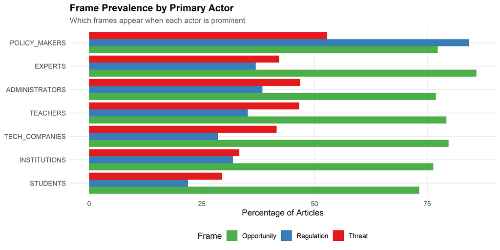

Figure 10: Actor-Frame Associations

```r
actor_frame_assoc <- clean_data %>%
  filter(primary_actor != "NONE") %>%
  group_by(primary_actor) %>%
  summarise(
    n = n(),
    threat = mean(frame_THREAT_present, na.rm = TRUE) * 100,
    opportunity = mean(frame_OPPORTUNITY_present, na.rm = TRUE) * 100,
    regulation = mean(frame_REGULATION_present, na.rm = TRUE) * 100,
    .groups = "drop"
  ) %>%
  arrange(desc(n))

actor_frame_long <- actor_frame_assoc %>%
  select(primary_actor, threat, opportunity, regulation) %>%
  pivot_longer(-primary_actor, names_to = "frame", values_to = "percentage") %>%
  mutate(frame = str_to_title(frame))

ggplot(actor_frame_long, aes(x = reorder(primary_actor, percentage), y = percentage, fill = frame)) +
  geom_col(position = "dodge") +
  scale_fill_manual(values = c("Threat" = "#e41a1c", "Opportunity" = "#4daf4a", "Regulation" = "#377eb8")) +
  coord_flip() +
  labs(
    title = "Frame Prevalence by Primary Actor",
    subtitle = "Which frames appear when each actor is prominent",
    x = NULL,
    y = "Percentage of Articles",
    fill = "Frame"
  )
```

## 3.6 Source Analysis

Outlet classification enables comparison across media types. Sources are categorized via pattern matching on domain names into tabloid, quality, regional, public, tech, education, and business press. The “Other” category captures unclassified sources. Frame prevalence differences across outlet types indicate systematic variation in news construction.

```r
# Classify outlets
outlet_classification <- tribble(
  ~pattern,                    ~outlet_type,
  "24sata",                    "Tabloid",
  "index",                     "Tabloid",
  "jutarnji",                  "Quality",
  "vecernji",                  "Quality",
  "slobodna.*dalmacija",       "Regional",
  "novi.*list",                "Regional",
  "dnevnik",                   "Quality",
  "hrt",                       "Public",
  "n1",                        "Quality",
  "net\\.hr",                  "Tabloid",
  "tportal",                   "Quality",
  "bug",                       "Tech",
  "skolski.*portal",           "Education",
  "srednja",                   "Education",
  "poslovni",                  "Business",
  "lider",                     "Business"
)

clean_data$outlet_type <- "Other"
for (i in seq_len(nrow(outlet_classification))) {
  matches <- str_detect(str_to_lower(clean_data$FROM), outlet_classification$pattern[i])
  clean_data$outlet_type[matches] <- outlet_classification$outlet_type[i]
}
```

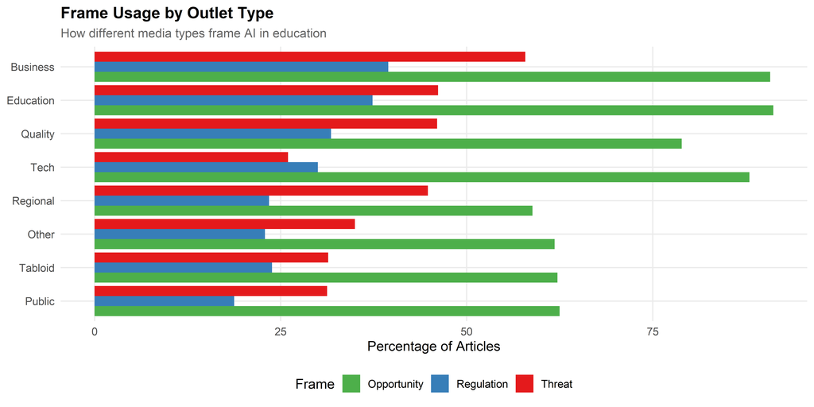

Figure 11: Coverage by Outlet Type

```r
outlet_type_stats <- clean_data %>%
  group_by(outlet_type) %>%
  summarise(
    n_articles = n(),
    pct_threat = mean(frame_THREAT_present, na.rm = TRUE) * 100,
    pct_opportunity = mean(frame_OPPORTUNITY_present, na.rm = TRUE) * 100,
    pct_regulation = mean(frame_REGULATION_present, na.rm = TRUE) * 100,
    mean_sentiment = mean(sentiment_score, na.rm = TRUE),
    .groups = "drop"
  ) %>%
  arrange(desc(n_articles))

outlet_type_long <- outlet_type_stats %>%
  select(outlet_type, pct_threat, pct_opportunity, pct_regulation) %>%
  pivot_longer(-outlet_type, names_to = "frame", values_to = "percentage") %>%
  mutate(frame = str_remove(frame, "pct_") %>% str_to_title())

ggplot(outlet_type_long, aes(x = reorder(outlet_type, percentage), y = percentage, fill = frame)) +
  geom_col(position = "dodge") +
  scale_fill_manual(values = c("Threat" = "#e41a1c", "Opportunity" = "#4daf4a", "Regulation" = "#377eb8")) +
  coord_flip() +
  labs(
    title = "Frame Usage by Outlet Type",
    subtitle = "How different media types frame AI in education",
    x = NULL,
    y = "Percentage of Articles",
    fill = "Frame"
  )
```

```r
outlet_summary <- outlet_type_stats %>%
  mutate(
    `Mean Sentiment` = round(mean_sentiment, 2),
    `% Threat` = paste0(round(pct_threat, 1), "%"),
    `% Opportunity` = paste0(round(pct_opportunity, 1), "%"),
    `% Regulation` = paste0(round(pct_regulation, 1), "%")
  ) %>%
  select(
    `Outlet Type` = outlet_type,
    Articles = n_articles,
    `Mean Sentiment`,
    `% Threat`,
    `% Opportunity`,
    `% Regulation`
  )

kable(outlet_summary) %>%
  kable_styling(bootstrap_options = c("striped", "hover"), full_width = FALSE)
```

Table 3: Summary Statistics by Outlet Type

| Outlet Type | Articles | Mean Sentiment | % Threat | % Opportunity | % Regulation |
| --- | --- | --- | --- | --- | --- |
| Other | 2879 | 0.17 | 35% | 61.8% | 22.9% |
| Quality | 365 | -0.12 | 46% | 78.9% | 31.8% |
| Regional | 192 | 0.26 | 44.8% | 58.9% | 23.4% |
| Tabloid | 172 | 0.23 | 31.4% | 62.2% | 23.8% |
| Education | 91 | 0.22 | 46.2% | 91.2% | 37.4% |
| Business | 76 | 0.12 | 57.9% | 90.8% | 39.5% |
| Tech | 50 | 0.32 | 26% | 88% | 30% |
| Public | 48 | -0.12 | 31.2% | 62.5% | 18.8% |

## 3.7 Statistical Tests

Statistical tests provide inferential support for observed patterns. We employ non-parametric and parametric tests appropriate to variable types.

### 3.7.1 Frame-Outlet Association

A chi-square test of independence assesses whether dominant frame distribution varies significantly across outlet types. A significant result (p < 0.05) indicates that outlet type and frame usage are not independent—different media types systematically prefer different frames. Note: cells with expected counts below 5 may inflate Type I error.

```r
frame_outlet_table <- table(clean_data$dominant_frame, clean_data$outlet_type)
chisq_result <- chisq.test(frame_outlet_table)

cat("Chi-Square Test: Dominant Frame vs. Outlet Type\n")
```

```
Chi-Square Test: Dominant Frame vs. Outlet Type
```

```r
cat("X² =", round(chisq_result$statistic, 2), "\n")
```

```
X² = 210.9
```

```r
cat("df =", chisq_result$parameter, "\n")
```

```
df = 56
```

```r
cat("p-value =", format(chisq_result$p.value, scientific = TRUE), "\n")
```

```
p-value = 8.234689e-20
```

```r
if (chisq_result$p.value < 0.05) {
  cat("\nResult: Significant association between outlet type and frame usage (p < 0.05)\n")
}
```

```
Result: Significant association between outlet type and frame usage (p < 0.05)
```

### 3.7.2 Sentiment by Phase

One-way ANOVA tests whether mean sentiment differs significantly across narrative phases. A significant F-statistic indicates at least one phase differs from others. Tukey’s HSD post-hoc test identifies specific pairwise differences while controlling family-wise error rate. Positive differences indicate the first-named phase has higher sentiment than the second.

```r
anova_result <- aov(sentiment_score ~ narrative_phase, data = clean_data)
anova_summary <- summary(anova_result)

cat("ANOVA: Sentiment Score by Narrative Phase\n")
```

```
ANOVA: Sentiment Score by Narrative Phase
```

```r
print(anova_summary)
```

```
                  Df Sum Sq Mean Sq F value    Pr(>F)
narrative_phase    2     47  23.256   10.27 0.0000357 ***
Residuals       3870   8767   2.265
---
Signif. codes:  0 '***' 0.001 '**' 0.01 '*' 0.05 '.' 0.1 ' ' 1
```

```r
if (anova_summary[[1]]$`Pr(>F)`[1] < 0.05) {
  cat("\nPost-hoc Tukey HSD:\n")
  tukey_result <- TukeyHSD(anova_result)
  print(tukey_result)
}
```

```
Post-hoc Tukey HSD:
  Tukey multiple comparisons of means
    95% family-wise confidence level

Fit: aov(formula = sentiment_score ~ narrative_phase, data = clean_data)

$narrative_phase
                                               diff         lwr       upr
Phase 2: Debate-Phase 1: Emergence       0.24017336  0.11155332 0.3687934
Phase 3: Integration-Phase 1: Emergence  0.20828021 -0.07564788 0.4922083
Phase 3: Integration-Phase 2: Debate    -0.03189315 -0.32818983 0.2644035
                                            p adj
Phase 2: Debate-Phase 1: Emergence      0.0000366
Phase 3: Integration-Phase 1: Emergence 0.1978160
Phase 3: Integration-Phase 2: Debate    0.9654994
```

# 4 Extended Analysis

## 4.1 Academic Calendar Effects

Educational discourse often intensifies around key calendar events. We examine whether media framing shifts during exam periods (državna matura, semester exams) and back-to-school seasons.

```r
# Create academic calendar periods
clean_data <- clean_data %>%
  mutate(
    month_num = month(DATE),
    academic_period = case_when(
      month_num %in% c(6, 7) ~ "Matura/Exams (Jun-Jul)",
      month_num %in% c(8, 9) ~ "Back to School (Aug-Sep)",
      month_num %in% c(1, 2) ~ "Mid-Year Exams (Jan-Feb)",
      TRUE ~ "Regular Period"
    ),
    academic_period = factor(academic_period, levels = c(
      "Matura/Exams (Jun-Jul)", "Back to School (Aug-Sep)",
      "Mid-Year Exams (Jan-Feb)", "Regular Period"
    ))
  )
```

### 4.1.1 Frame Prevalence by Academic Period

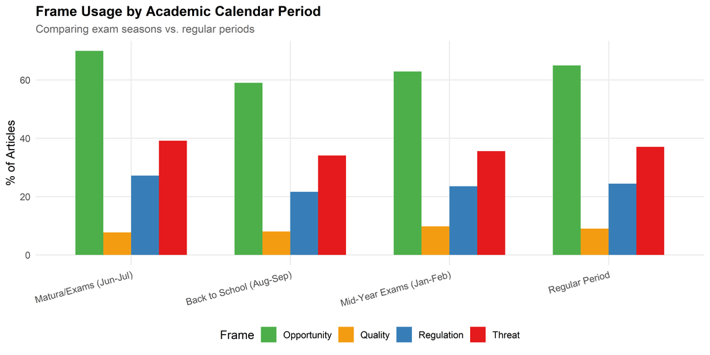

Figure 12: Frame Distribution by Academic Calendar Period

```r
calendar_stats <- clean_data %>%
  group_by(academic_period) %>%
  summarise(
    n = n(),
    threat = mean(frame_THREAT_present, na.rm = TRUE) * 100,
    opportunity = mean(frame_OPPORTUNITY_present, na.rm = TRUE) * 100,
    regulation = mean(frame_REGULATION_present, na.rm = TRUE) * 100,
    quality = mean(frame_QUALITY_present, na.rm = TRUE) * 100,
    mean_sentiment = mean(sentiment_score, na.rm = TRUE),
    .groups = "drop"
  )

calendar_stats %>%
  pivot_longer(c(threat, opportunity, regulation, quality),
               names_to = "frame", values_to = "percentage") %>%
  mutate(frame = str_to_title(frame)) %>%
  ggplot(aes(x = academic_period, y = percentage, fill = frame)) +
  geom_col(position = "dodge", width = 0.7) +
  scale_fill_manual(values = c("Threat" = "#e41a1c", "Opportunity" = "#4daf4a",
                                "Regulation" = "#377eb8", "Quality" = "#f39c12")) +
  labs(
    title = "Frame Usage by Academic Calendar Period",
    subtitle = "Comparing exam seasons vs. regular periods",
    x = NULL, y = "% of Articles", fill = "Frame"
  ) +
  theme(axis.text.x = element_text(angle = 15, hjust = 1))
```

### 4.1.2 Monthly Patterns

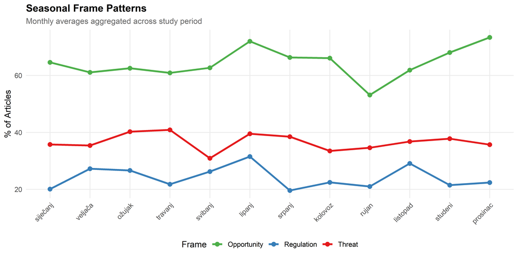

Figure 13: Frame Prevalence by Month (Aggregated Across Years)

```r
monthly_by_month <- clean_data %>%
  mutate(month_name = month(DATE, label = TRUE, abbr = FALSE)) %>%
  group_by(month_name) %>%
  summarise(
    n = n(),
    threat = mean(frame_THREAT_present, na.rm = TRUE) * 100,
    opportunity = mean(frame_OPPORTUNITY_present, na.rm = TRUE) * 100,
    regulation = mean(frame_REGULATION_present, na.rm = TRUE) * 100,
    .groups = "drop"
  )

monthly_by_month %>%
  pivot_longer(c(threat, opportunity, regulation),
               names_to = "frame", values_to = "percentage") %>%
  mutate(frame = str_to_title(frame)) %>%
  ggplot(aes(x = month_name, y = percentage, color = frame, group = frame)) +
  geom_line(linewidth = 1.2) +
  geom_point(size = 2.5) +
  scale_color_manual(values = c("Threat" = "#e41a1c", "Opportunity" = "#4daf4a",
                                 "Regulation" = "#377eb8")) +
  labs(
    title = "Seasonal Frame Patterns",
    subtitle = "Monthly averages aggregated across study period",
    x = NULL, y = "% of Articles", color = "Frame"
  ) +
  theme(axis.text.x = element_text(angle = 45, hjust = 1))
```

### 4.1.3 Statistical Test: Calendar Effects

```r
# ANOVA for threat frame by academic period
calendar_aov_threat <- aov(frame_THREAT_present ~ academic_period, data = clean_data)
calendar_aov_summary <- summary(calendar_aov_threat)

cat("ANOVA: Threat Frame by Academic Period\n")
```

```
ANOVA: Threat Frame by Academic Period
```

```r
print(calendar_aov_summary)
```

```
                  Df Sum Sq Mean Sq F value Pr(>F)
academic_period    3    0.9  0.3041   1.306  0.271
Residuals       3869  900.8  0.2328
```

```r
if (calendar_aov_summary[[1]]$`Pr(>F)`[1] < 0.05) {
  cat("\nPost-hoc Tukey HSD:\n")
  print(TukeyHSD(calendar_aov_threat))
}
```

```r
calendar_table <- calendar_stats %>%
  mutate(
    `% Threat` = paste0(round(threat, 1), "%"),
    `% Opportunity` = paste0(round(opportunity, 1), "%"),
    `% Regulation` = paste0(round(regulation, 1), "%"),
    `Mean Sentiment` = round(mean_sentiment, 2)
  ) %>%
  select(
    `Academic Period` = academic_period,
    Articles = n,
    `% Threat`, `% Opportunity`, `% Regulation`, `Mean Sentiment`
  )

kable(calendar_table) %>%
  kable_styling(bootstrap_options = c("striped", "hover"), full_width = FALSE)
```

Table 4: Summary Statistics by Academic Period

| Academic Period | Articles | % Threat | % Opportunity | % Regulation | Mean Sentiment |
| --- | --- | --- | --- | --- | --- |
| Matura/Exams (Jun-Jul) | 802 | 39.2% | 70% | 27.2% | 0.34 |
| Back to School (Aug-Sep) | 522 | 34.1% | 59% | 21.6% | 0.20 |
| Mid-Year Exams (Jan-Feb) | 531 | 35.6% | 62.9% | 23.5% | 0.08 |
| Regular Period | 2018 | 37.1% | 65% | 24.4% | 0.07 |

## 4.2 Political Orientation of Sources

Media outlets differ not only in format but in editorial orientation. We classify Croatian outlets along a conservative-liberal dimension to examine whether political leaning correlates with AI framing.

### 4.2.1 Classification Schema

| Orientation | Outlets | Rationale |
| --- | --- | --- |
| **Conservative** | Večernji list, HRT | Traditional, establishment-aligned |
| **Liberal** | 24sata, Index, Jutarnji, Slobodna Dalmacija, Novi list, N1, T-portal, Net.hr | Progressive, commercially-oriented |

```r
# Classify by political orientation
clean_data <- clean_data %>%
  mutate(
    political_orientation = case_when(
      str_detect(str_to_lower(FROM), "vecernji|hrt") ~ "Conservative",
      str_detect(str_to_lower(FROM), "24sata|index|jutarnji|slobodna|novi.?list|n1|tportal|net\\.hr") ~ "Liberal",
      TRUE ~ "Unclassified"
    )
  )

# Summary stats
political_n <- clean_data %>%
  count(political_orientation) %>%
  filter(political_orientation != "Unclassified")

cat("Sample sizes:\n")
```

```
Sample sizes:
```

```r
print(political_n)
```

```
  political_orientation   n
1          Conservative 103
2               Liberal 549
```

### 4.2.2 Frame Comparison by Political Orientation

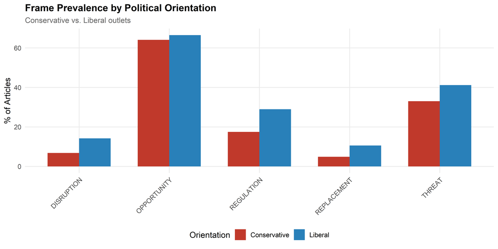

Figure 14: Frame Usage by Political Orientation of Outlet

```r
political_stats <- clean_data %>%
  filter(political_orientation != "Unclassified") %>%
  group_by(political_orientation) %>%
  summarise(
    n = n(),
    threat = mean(frame_THREAT_present, na.rm = TRUE) * 100,
    opportunity = mean(frame_OPPORTUNITY_present, na.rm = TRUE) * 100,
    regulation = mean(frame_REGULATION_present, na.rm = TRUE) * 100,
    disruption = mean(frame_DISRUPTION_present, na.rm = TRUE) * 100,
    replacement = mean(frame_REPLACEMENT_present, na.rm = TRUE) * 100,
    quality = mean(frame_QUALITY_present, na.rm = TRUE) * 100,
    mean_sentiment = mean(sentiment_score, na.rm = TRUE),
    .groups = "drop"
  )

political_stats %>%
  select(political_orientation, threat, opportunity, regulation, disruption, replacement) %>%
  pivot_longer(-political_orientation, names_to = "frame", values_to = "percentage") %>%
  mutate(frame = str_to_upper(frame)) %>%
  ggplot(aes(x = frame, y = percentage, fill = political_orientation)) +
  geom_col(position = "dodge", width = 0.7) +
  scale_fill_manual(values = c("Conservative" = "#c0392b", "Liberal" = "#2980b9")) +
  labs(
    title = "Frame Prevalence by Political Orientation",
    subtitle = "Conservative vs. Liberal outlets",
    x = NULL, y = "% of Articles", fill = "Orientation"
  ) +
  theme(axis.text.x = element_text(angle = 45, hjust = 1))
```

### 4.2.3 Sentiment Distribution

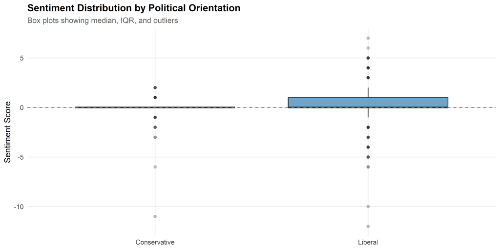

Figure 15: Sentiment Distribution by Political Orientation

```r
clean_data %>%
  filter(political_orientation != "Unclassified") %>%
  ggplot(aes(x = political_orientation, y = sentiment_score, fill = political_orientation)) +
  geom_boxplot(alpha = 0.7, outlier.alpha = 0.3) +
  geom_hline(yintercept = 0, linetype = "dashed", color = "gray50") +
  scale_fill_manual(values = c("Conservative" = "#c0392b", "Liberal" = "#2980b9")) +
  labs(
    title = "Sentiment Distribution by Political Orientation",
    subtitle = "Box plots showing median, IQR, and outliers",
    x = NULL, y = "Sentiment Score"
  ) +
  theme(legend.position = "none")
```

### 4.2.4 Statistical Test: Political Orientation

```r
# T-test for sentiment differences
political_ttest <- t.test(
  sentiment_score ~ political_orientation,
  data = clean_data %>% filter(political_orientation != "Unclassified")
)

cat("Independent Samples t-test: Sentiment by Political Orientation\n")
```

```
Independent Samples t-test: Sentiment by Political Orientation
```

```r
cat("  t =", round(political_ttest$statistic, 3), "\n")
```

```
  t = -2.174
```

```r
cat("  df =", round(political_ttest$parameter, 1), "\n")
```

```
  df = 153.7
```

```r
cat("  p-value =", format(political_ttest$p.value, digits = 4), "\n")
```

```
  p-value = 0.03127
```

```r
cat("  Mean (Conservative):", round(political_ttest$estimate[1], 3), "\n")
```

```
  Mean (Conservative): -0.165
```

```r
cat("  Mean (Liberal):", round(political_ttest$estimate[2], 3), "\n")
```

```
  Mean (Liberal): 0.188
```

```r
# Chi-square for frame-orientation association
political_frame_table <- table(
  clean_data$dominant_frame[clean_data$political_orientation != "Unclassified"],
  clean_data$political_orientation[clean_data$political_orientation != "Unclassified"]
)
political_chisq <- chisq.test(political_frame_table)

cat("\nChi-Square Test: Dominant Frame vs. Political Orientation\n")
```

```
Chi-Square Test: Dominant Frame vs. Political Orientation
```

```r
cat("  χ² =", round(political_chisq$statistic, 2), "\n")
```

```
  χ² = 8.82
```

```r
cat("  df =", political_chisq$parameter, "\n")
```

```
  df = 8
```

```r
cat("  p-value =", format(political_chisq$p.value, scientific = TRUE), "\n")
```

```
  p-value = 3.580372e-01
```

```r
political_table <- political_stats %>%
  mutate(
    `% Threat` = paste0(round(threat, 1), "%"),
    `% Opportunity` = paste0(round(opportunity, 1), "%"),
    `% Regulation` = paste0(round(regulation, 1), "%"),
    `% Replacement` = paste0(round(replacement, 1), "%"),
    `Mean Sentiment` = round(mean_sentiment, 2)
  ) %>%
  select(
    Orientation = political_orientation,
    Articles = n,
    `% Threat`, `% Opportunity`, `% Regulation`, `% Replacement`, `Mean Sentiment`
  )

kable(political_table) %>%
  kable_styling(bootstrap_options = c("striped", "hover"), full_width = FALSE)
```

Table 5: Summary Statistics by Political Orientation

| Orientation | Articles | % Threat | % Opportunity | % Regulation | % Replacement | Mean Sentiment |
| --- | --- | --- | --- | --- | --- | --- |
| Conservative | 103 | 33% | 64.1% | 17.5% | 4.9% | -0.17 |
| Liberal | 549 | 41.2% | 66.5% | 29% | 10.6% | 0.19 |

## 4.3 Actor Context Analysis

While frequency counts reveal *who* is mentioned, they do not capture *how* actors are discussed. This section examines the linguistic context surrounding key actors through co-occurrence analysis and frame associations.

### 4.3.1 Methodological Approach

For each actor category, we:

1. Extract text windows (±50 characters) around actor mentions
2. Identify frequently co-occurring terms
3. Examine frame associations when each actor is primary

This reveals the semantic fields and evaluative contexts surrounding different stakeholders.

### 4.3.2 Co-occurring Terms by Actor

```r
# Function to extract context windows
extract_context_words <- function(texts, actor_terms, window = 50) {
  all_words <- c()

  for (text in texts) {
    if (is.na(text)) next
    text_lower <- str_to_lower(text)
    pattern <- paste0("\\b(", paste(actor_terms, collapse = "|"), ")\\b")

    matches <- str_locate_all(text_lower, pattern)[[1]]
    if (nrow(matches) == 0) next

    for (i in seq_len(nrow(matches))) {
      start <- max(1, matches[i, 1] - window)
      end <- min(nchar(text), matches[i, 2] + window)
      context <- substr(text_lower, start, end)
      words <- unlist(str_extract_all(context, "\\b[a-zčćžšđ]{4,}\\b"))
      all_words <- c(all_words, words)
    }
  }

  # Remove actor terms and stopwords
  stopwords_hr <- c("koji", "koja", "koje", "biti", "jest", "nisu", "mogu", "može",
                    "tako", "više", "manje", "samo", "također", "prema", "kroz",
                    "ovaj", "ova", "ovo", "svoj", "svoja", "svoje", "nego", "kada",
                    "sada", "nakon", "prije", "zato", "stoga", "međutim", "ipak")
  all_words <- all_words[!all_words %in% c(actor_terms, stopwords_hr)]

  word_counts <- sort(table(all_words), decreasing = TRUE)
  data.frame(
    word = names(word_counts),
    n = as.integer(word_counts)
  ) %>% head(15)
}

# Define actor terms
student_terms <- c("student", "studenti", "studentica", "učenik", "učenici", "učenica", "đak", "maturant")
teacher_terms <- c("učitelj", "učitelji", "učiteljica", "nastavnik", "nastavnici", "profesor", "profesori", "profesorica")
institution_terms <- c("škola", "škole", "fakultet", "sveučilište", "ministarstvo", "gimnazija", "osnovna")

# Extract co-occurring words (using sample for efficiency)
set.seed(42)
sample_texts <- sample(clean_data$FULL_TEXT, min(1000, nrow(clean_data)))

student_context <- extract_context_words(sample_texts, student_terms)
teacher_context <- extract_context_words(sample_texts, teacher_terms)
institution_context <- extract_context_words(sample_texts, institution_terms)
```

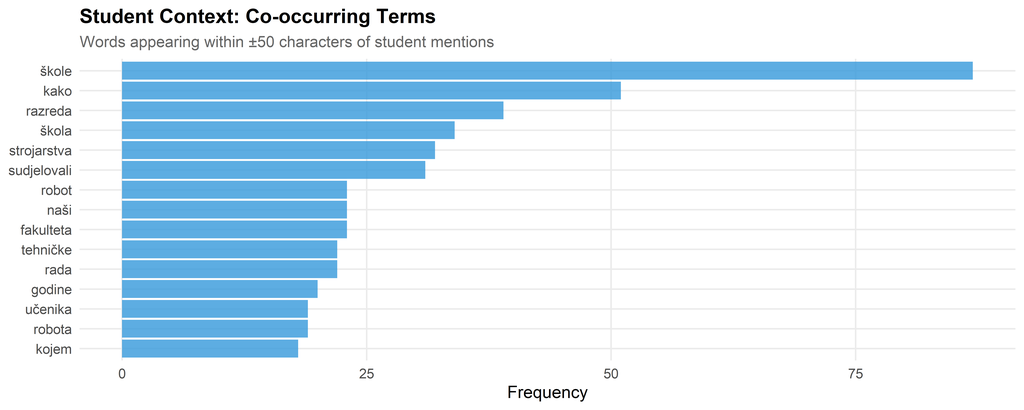

Figure 16: Most Frequent Terms Co-occurring with Student Mentions

```r
if (nrow(student_context) > 0) {
  ggplot(student_context, aes(x = reorder(word, n), y = n)) +
    geom_col(fill = "#3498db", alpha = 0.8) +
    coord_flip() +
    labs(
      title = "Student Context: Co-occurring Terms",
      subtitle = "Words appearing within ±50 characters of student mentions",
      x = NULL, y = "Frequency"
    )
}
```

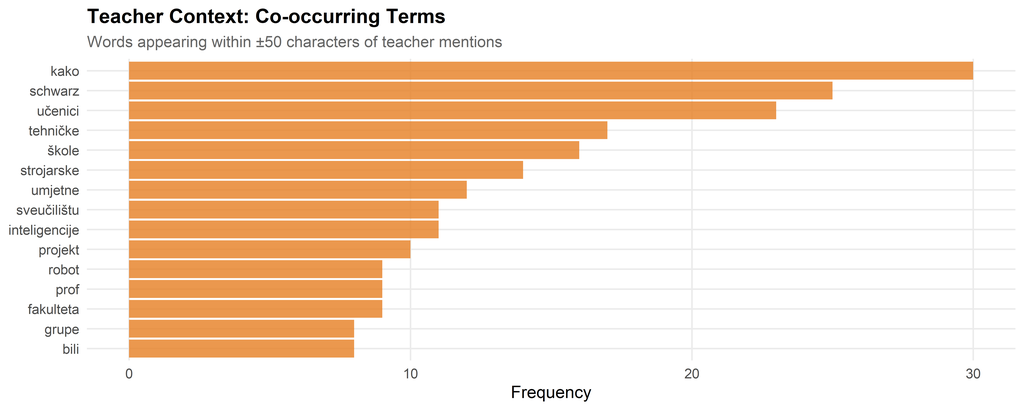

Figure 17: Most Frequent Terms Co-occurring with Teacher Mentions

```r
if (nrow(teacher_context) > 0) {
  ggplot(teacher_context, aes(x = reorder(word, n), y = n)) +
    geom_col(fill = "#e67e22", alpha = 0.8) +
    coord_flip() +
    labs(
      title = "Teacher Context: Co-occurring Terms",
      subtitle = "Words appearing within ±50 characters of teacher mentions",
      x = NULL, y = "Frequency"
    )
}
```

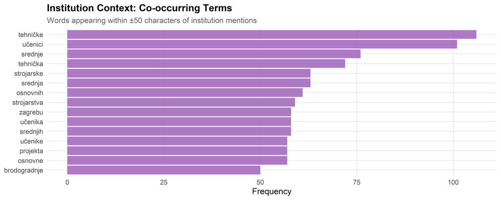

Figure 18: Most Frequent Terms Co-occurring with Institution Mentions

```r
if (nrow(institution_context) > 0) {
  ggplot(institution_context, aes(x = reorder(word, n), y = n)) +
    geom_col(fill = "#9b59b6", alpha = 0.8) +
    coord_flip() +
    labs(
      title = "Institution Context: Co-occurring Terms",
      subtitle = "Words appearing within ±50 characters of institution mentions",
      x = NULL, y = "Frequency"
    )
}
```